# Classification of Customer Reviews on a Product

# TF-IDF Calculation

**TF-IDF** stands for term frequency-inverse document frequency

**TF** is calculated at document level

**IDF** Measure how common a term in entire corpus (weight of term in a corpus)

IDF is calculated at corpus level ( IDF close to 1 implies term is too common in corpus and IDF close to 5 means term is too rare in entire corpus)

The **TF-IDF** value is specific to a single document (d) whereas IDF depends on the entire corpus

```python
from sklearn.feature_extraction.text import TfidfTransformer
```

```python
tfidf_transformer=TfidfTransformer().fit(review_bow)
```

```python
review_tfidf=tfidf_transformer.transform(review_bow)
```

lets see the TF-IDF values for first review

```python
print(review_tfidf[0])#to check tf-idf of first row
```

```
  (0, 355)	0.8279581025038976
  (0, 273)	0.23363053921632188
  (0, 191)	0.25840691546251787
  (0, 146)	0.30076241041416185
  (0, 142)	0.30076241041416185
  (0, 90)	0.11050774926904397
```

to see IDF of a particular word e.g amazing

```python
tfidf_transformer.idf_[bow_transformer.vocabulary_['amazing']]
```

```
4.228826155721369
```

## Train Test Split

```python
from sklearn.model_selection import train_test_split
```

```python
X_train, X_test, y_train, y_test = train_test_split(review_tfidf, review['Label'], test_size=0.3 ,random_state=78)
```

## Training a Model

The Naive Bayes classifier is one of the most basic text classification techniques with various applications in email spam detection, document categorization, language detection and sentiment detection

```python
from sklearn.naive_bayes import MultinomialNB
```

```python
review_model=MultinomialNB().fit(X_train,y_train)
```

```python
all_pred=review_model.predict(X_test)
```

```python
all_pred
```

```
array(['good', 'good', 'good', 'good', 'good', 'good', 'good', 'good',
       'good', 'good', 'good', 'good', 'good', 'good', 'good', 'good',
       'good', 'good', 'good', 'good', 'good', 'good', 'good', 'good',
       'good', 'good', 'good', 'good', 'good', 'good'], dtype='<U4')
```

```python
data=np.stack((y_test,all_pred),axis=1)
Actual_Predicted=pd.DataFrame(data,columns=['Actual','Predicted']) #to get dataframe of actual vs predicted
Actual_Predicted.head()
```

|  | Actual | Predicted |
| --- | --- | --- |
| 0 | good | good |
| 1 | good | good |
| 2 | good | good |
| 3 | good | good |
| 4 | good | good |

# Model Evaluation

since our corpus size is very small, and only few instance of bad reviews were included in test data examples. if any bad review was not predicted by the trained model, This means that there is no F-score to calculate for this label, and thus the F-score for this case is considered to be 0.0. this is why scikit-learn might through a warning we can ignore this warning by importing warnings

```python
import warnings
```

```python
warnings.filterwarnings('ignore')
```

```python
from sklearn.metrics import classification_report
```

```python
print(classification_report(y_test,all_pred))
```

```
              precision    recall  f1-score   support

         bad       0.00      0.00      0.00         5
        good       0.83      1.00      0.91        25

    accuracy                           0.83        30
   macro avg       0.42      0.50      0.45        30
weighted avg       0.69      0.83      0.76        30
```

# Creating a Data Pipeline

We can use SciKit Learn's pipeline capabilities to store a pipeline of workflow. This will allow us to set up all the transformations that we did so far. Let's see an example of how it works

```python
X1_train, X1_test, y1_train, y1_test = train_test_split(review['Reviews'], review['Label'], test_size=0.3,random_state=78 )
```

```python
from sklearn.pipeline import Pipeline
```

```python
pipline=Pipeline([
        ('bow',CountVectorizer(analyzer=text_process)),
        ('tfidf',TfidfTransformer()),
        ('classifier',MultinomialNB())
        ])
```

```python
pipline.fit(X1_train,y1_train)
```

```
Pipeline(memory=None,
         steps=[('bow',
                 CountVectorizer(analyzer=<function text_process at 0x00000228DDB44318>,
                                 binary=False, decode_error='strict',
                                 dtype=<class 'numpy.int64'>, encoding='utf-8',
                                 input='content', lowercase=True, max_df=1.0,
                                 max_features=None, min_df=1,
                                 ngram_range=(1, 1), preprocessor=None,
                                 stop_words=None, strip_accents=None,
                                 token_pattern='(?u)\\b\\w\\w+\\b',
                                 tokenizer=None, vocabulary=None)),
                ('tfidf',
                 TfidfTransformer(norm='l2', smooth_idf=True,
                                  sublinear_tf=False, use_idf=True)),
                ('classifier',
                 MultinomialNB(alpha=1.0, class_prior=None, fit_prior=True))],
         verbose=False)
```

```python
pred=pipline.predict(X1_test)
```

```python
data1=np.stack((y1_test,pred),axis=1)
Actual_Predicted_1=pd.DataFrame(data1,columns=['Actual','Predicted'])
Actual_Predicted_1.head()
```

|  | Actual | Predicted |
| --- | --- | --- |
| 0 | good | good |
| 1 | good | good |
| 2 | good | good |
| 3 | good | good |
| 4 | good | good |

```python
print(classification_report(y1_test,pred))
```

```
              precision    recall  f1-score   support

         bad       0.00      0.00      0.00         5
        good       0.83      1.00      0.91        25

    accuracy                           0.83        30
   macro avg       0.42      0.50      0.45        30
weighted avg       0.69      0.83      0.76        30
```

# Creating a Word Cloud

```python
from wordcloud import WordCloud
```

```python
def my_wordcloud(data):
    wordcloud = WordCloud(
        background_color = 'White',
        max_words = 200,
        max_font_size = 45,
        scale = 3,
        random_state = 42
    ).generate(str(data))

    fig = plt.figure(1, figsize = (16, 10))
    plt.axis('off')
    plt.imshow(wordcloud)
    plt.show()
```

# Word Cloud of Good Reviews

```python
good_review=review[review['Label']=='good']
```

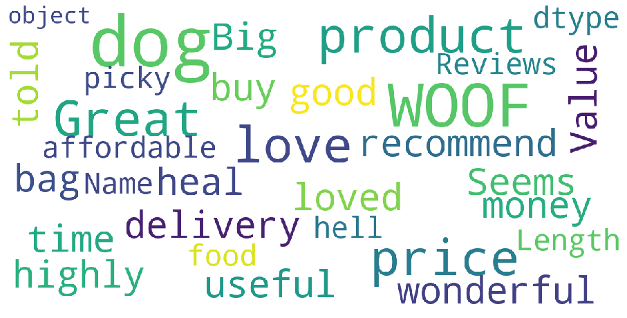

```python
my_wordcloud(good_review['Reviews'])
```

# Word Cloud of Bad Reviews

```python
bad_review=review[review['Label']=='bad']
```

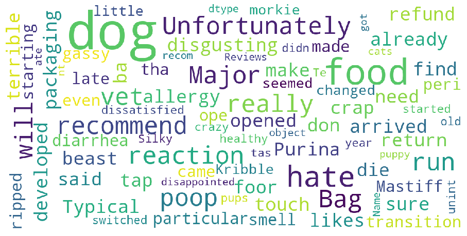

```python
my_wordcloud(bad_review['Reviews'])
```

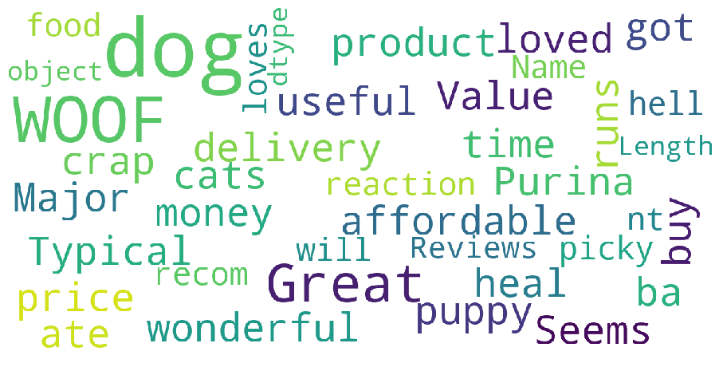

```python
my_wordcloud(review['Reviews']) #overall
```

# Conclusion

Sometimes Retailers read few random reviews and get overwhelmed, but it's always a good idea to get the overall results. This idea of text classification can be enhanced further to different real world scenarios e.g. campaign analysis, marketing strategies etc. More classes can be introduced, and more text processing can be performed.

# References

1: Data Science for Business by Foster Provost (Author), Tom Fawcett (Author)

2: https://www.geeksforgeeks.org/removing-stop-words-nltk-python/

3: https://towardsdatascience.com/topic-modeling-and-latent-dirichlet-allocation-in-python-9bf156893c24

4: https://www.udemy.com/course/python-for-data-science-and-machine-learning-bootcamp/